# Breaking the prejudice habit: Mechanisms, timecourse, and longevity - ScienceDirect

### 2.3. Replication analyses – discussion

In sum, our findings only partially replicate the findings of Devine et al. (2012). Although intervention participants increased in concern more than control participants, they did not decrease in implicit bias more than control participants. Although intervention participants showed an initial increase in discrepancies relative to control participants, this increase faded in the latter part of the study.

The reason for the inconsistencies between our results and those reported by Devine et al. (2012) is unclear. On the one hand, our sample is more than three times that used by Devine et al. (2012), suggesting that our results are less susceptible to sampling error. The persistent decrease in implicit bias and increase in discrepancies results reported by Devine and colleagues could therefore be false positives. On the other hand, as outlined in Table 1, the current study differed from that conducted by Devine et al. (2012) in six ways, and these differences in procedure could have interfered with the detection of the intervention's effects. In particular, the frequent follow-up assessment schedule could have induced practice effects on the IAT, which may have obscured any true effects of the intervention on implicit bias. Frequently responding to questions about race may have made all participants more sensitive to racial issues, a sensitivity that could have differentially impacted intervention and control participants, perhaps causing the decrease in discrepancies in the latter parts of the study.

Although the interpretation of our findings on implicit bias and discrepancies is unclear, the interpretation of our findings for concern is more straightforward. The habit-breaking intervention appears to have a robust, enduring impact on the degree to which people characterize racial discrimination as a problem. Moreover, some of our other results, reported below, suggest that concern may be as important or more important than implicit bias with regard to empowering people to take steps to address bias. We will return to these issues in the General Discussion.

### 2.4. Race-related thoughts, race-related conversations, and interracial interactions

We measured race-related thoughts, race-related conversations, and interracial interactions as potential mechanisms for the intervention's effects. We measured both the quantity of these outcomes reported by the participants and the content of these outcomes, as coded from the participants' open-ended descriptions. We first assessed the effects of the habit-breaking intervention on the quantity and content of thoughts, conversations, and interactions, after which we assessed the relationships between the quantity and content variables and implicit bias, concern, and should-would discrepancies.

#### 2.4.1. The habit-breaking intervention's effects on quantity and content

Participants reported a relatively small total number of race-related thoughts (*M* = 3.64, *SD* = 5.69), race-related conversations (*M* = 1.86, *SD* = 4.00), and interracial interactions (*M* = 8.13, *SD* = 8.70) over the course of the study. As shown in Fig. 3, there were no differences across the intervention and control conditions in the change in the daily reported rate of any of the three variables.<sup>3</sup> The only effects that we observed were steady decreases in the daily reported rate of thoughts *b* = 0.871, 95% CI = [0.843, 0.899], conversations *b* = 0.890, 95% CI = [0.845, 0.931], and interactions *b* = 0.895, 95% CI = [0.877, 0.911]. Full results for these models are available at https://osf.io/a3c8h/.

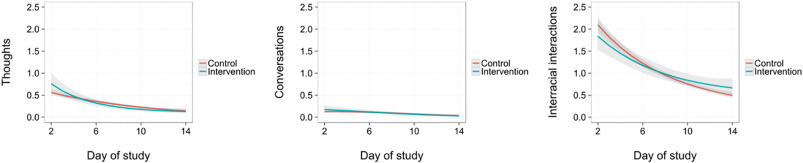

Fig. 3. Changes over time in the control and training conditions in the number of reported daily race-related thoughts, race-related conversations, and interracial interactions. Envelopes indicate ± 1 Wald standard error of the estimate.

#### 2.4.2. Relationships with the main study outcomes

A predictor measured multiple times for each person can be associated with an outcome in two ways (Raudenbush & Bryk, 2002). First, a person's *average level* of the predictor – in other words, the variance between people – can be associated with the outcome. Second, a person's *change* in the predictor – in other words, the variance within people – can be associated with the outcome. To examine whether these components of the quantity of race-related thoughts, race-related conversations, and interracial interactions were associated with the IAT, concern, should, woulds, and discrepancies, we first put the quantity variables on a common metric by dividing them by the amount of time that had passed since the last measurement, resulting in rates per day.<sup>5</sup> We then constructed indicators of between-person variance by finding, for each person, their average daily rates of thoughts, conversations, and interactions. We constructed indicators of within-person change by, for each person, subtracting their mean rates from each of their occasion-specific rates (Enders & Tofighi, 2007). Finally, we fit separate models, each of which simultaneously predicted each of our outcome variables from the between-person and within-person indicators for either thoughts, conversations, or interactions.

As shown in Table 5, controlling for condition and its interactions with time, the quantity of race-related thoughts and conversations was not associated with any of the main study outcomes. The one exception was that a person's average daily rate of race-related conversations was associated with smaller should-would discrepancies, *b* = − 0.088, 95% CI = [− 0.174, − 0.001]. In contrast, the quantity of interracial interactions was more strongly associated with the main study outcomes. Controlling for condition and its interactions with time, a person's average level of interracial interactions was associated with smaller should-would discrepancies, *b* = − 0.053, 95% CI = [− 0.097, − 0.011], a relationship that was driven by lower levels of woulds, *b* = − 0.059, 95% CI = [− 0.099, − 0.020]. Within-person increases in the daily rate of interactions was associated with both change in IAT bias, *b* = − 0.044, 95% CI = [− 0.078, − 0.011], and increasingly strict standards for one's race-related behavior, *b* = − 0.106, 95% CI = [− 0.207, − 0.004]. None of the quantity variables was associated with concern.

Table 5. The relationships between the quantity and content of race-related thoughts, conversations, and interactions and the IAT, concern, discrepancies, and the components of discrepancies, shoulds and woulds.

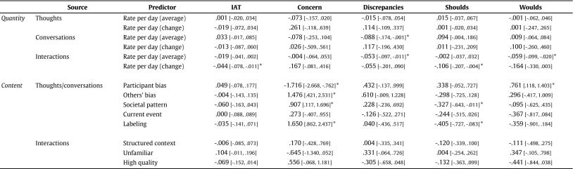

*Note:* The quantity variables were calculated by dividing the reported quantities of race-related thoughts and conversations and interracial interactions and dividing by the elapsed time since the last measurement of these variables. We used each participant's average rate of change and the differences between their average rate and their occasion-specific rates as predictors in an LMEM, with random slopes for the centered occasion-specific rates. For the content variables, we calculated the proportion of each participant's descriptions that were coded in each category and used these proportions as predictors in an LMEM. All 95% CIs were derived using profile likelihood. All models contained effects for condition, linear and quadratic effects of time, interactions between condition and linear and quadratic time, random intercepts for each participant, and random slopes for linear and quadratic time.

We also assessed whether the content of the participants' race-related thoughts, race-related conversations, and interracial interactions was associated with the main study outcomes. As a reminder, we could only assess content when the participants reported a non-zero number of thoughts, conversations, and interactions. This means that we only had a sufficient number of responses for each person to estimate average content for each person, rather than both the average content and the within-person change in content. We estimated between-person content by calculating the proportion of each participant's responses that fell in each coding category.

As shown in Table 5 and in contrast to the quantity variable results, several of the content variables were associated with to follow-up concern about discrimination, even controlling for condition and its interactions with time. A higher proportion of thought and conversation descriptions in which the participants themselves acted biased was associated with lower levels of follow-up concern, *b* = − 1.72, 95% CI = [− 2.67, − 0.76]. Noting the position of Black people in society was associated with higher concern, *b* = 0.91, 95% CI = [0.12, 1.69], as was noticing others act with bias, *b* = 1.48, 95% CI = [0.42, 2.53], and labeling bias as wrong, *b* = 1.65, 95% CI = [0.86, 2.44]. The relationships between noticing others act with bias and labeling bias as wrong on the one hand and concern on the other are particularly interesting given that the habit-breaking changed these outcomes. Due to ambiguity in how to estimate, in a nested design, the indirect effects of dichotomous mediators in the presence of variably spaced time points across participants, we did not conduct a formal mediation analysis. Nevertheless, our combined results suggest that the habit-breaking intervention exerts its impacts on concern because it orients people to the behavior of others and encourages people to label behaviors as explicitly wrong.

In addition to these relationships with concern, the proportion of descriptions in which the participants reported that they acted with bias was positively associated with woulds, *b* = 0.76, 95% CI = [0.12, 1.40], and the proportion of incidents that were labeled as wrong was negatively associated with shoulds, *b* = − 0.41, 95% CI = [− 0.73, − 0.08]. Finally, noticing patterns involving Black people in society was associated with stricter standards for one's race-related behavior, *b* = − 0.33, 95% CI = [− 0.64, − 0.01]. There were no relationships between the content of interracial interactions and the main study outcomes.

### 2.5. Strategy use

Whereas the analyses above include both intervention and control participants, the remaining set of Phase 1 analyses include only intervention participants. These analyses assess the intervention participants' patterns of strategy use, as well as whether strategy use is associated with the main study outcomes.

#### 2.5.1. Patterns of strategy use

Participants reported using one of the strategies an average of 8.93 times (*SD* = 13.51) during the two weeks following the intervention. Each individual strategy was used infrequently — for all five strategies, the modal amount of strategy use was 0, and all strategies except individuating were used less than two times on average; stereotype replacement *M* = 1.50, *SD* = 2.87, counterstereotypic imaging *M* = 1.54, *SD* = 2.80, individuating *M* = 2.46, *SD* = 4.52, perspective taking *M* = 1.85, *SD* = 3.23, contact *M* = 1.58, *SD* = 3.48.

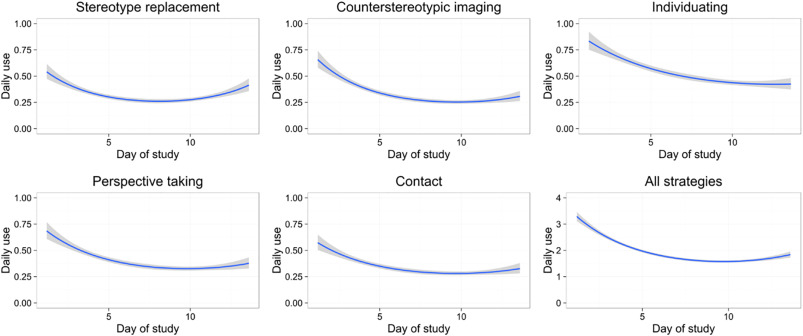

Fig. 4. Changes over time in the daily usage of each strategy. Envelopes indicate ± 1 Wald standard error of the estimate.

#### 2.5.2. Relationships with the main study outcomes

Just as with the quantities of race-related thoughts, race-related conversations, and interracial interactions, both a person's average rate of strategy use and the within-person change in this rate could be associated with the main study outcomes. We therefore calculated, for each strategy, each person's average daily rate of use, as well as the differences between a person's occasion-specific rates and their average rate (Enders & Tofighi, 2007). We then fit separate models, each of which simultaneously predicted the IAT, concern, shoulds, woulds, and discrepancies from the between-person and within-person indicators for use of one of the five strategies.<sup>6</sup>

Table 6. The relationships within the intervention condition between strategy use and the IAT, concern, discrepancies, and the components of discrepancies, shoulds and woulds.

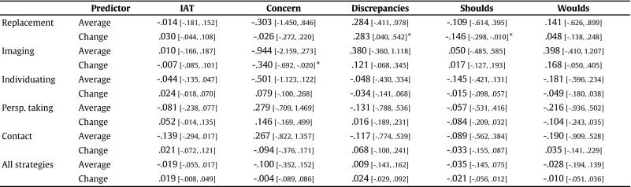

*Note:* Each strategy use variable was derived by dividing the number of uses of the strategy by the time since the last measurement. We then used both each participant's average daily rate and the differences between their occasion-specific daily rates and this average as predictors in an LMEM, along with a random slope for the centered occasion-specific rates. All 95% CIs were derived using profile likelihood. All models also contained effects of condition, linear and quadratic time, a random intercept for each participant, and random slopes for linear and quadratic time.

## 3. Phase 2

### 3.1. Overview

Two years after Phase 1, we conducted an exploratory study in which we measured the main study outcomes from Phase 1 and three behaviors that could plausibly be affected by the habit-breaking intervention. To that end, participants from Phase 1, who were kept unaware of the new study's connection to Phase 1, were invited to participate in a survey about student engagement with issues that affect the university. They learned we were evaluating student interest in a potential new online section of the campus student newspaper. As part of this evaluation process, the participants read an essay, supposedly written by another student, that argued that racial stereotypes are harmless, cognitively efficient, and are unpopular only because of a desire to be politically correct. Participants then had a chance to both privately rate their agreement with the essay and publicly post a comment about the essay's content. Finally, at the end of the study, they were given the chance to donate any amount of their compensation to a charity that has the mission of eliminating racial discrimination.

As part of its emphasis on awareness, the slideshow that forms the basis of the habit-breaking intervention specifically mentions the importance of detecting and labeling as wrong instances of bias in the social environment. We therefore reasoned that, to the extent that the habit-breaking intervention has effects that endure, intervention participants should be more likely to privately disagree with the content of the essay. If the habit-breaking intervention also leads people to make their views public, intervention participants may also be more likely to disagree with the essay publicly in their comments. Because reading and responding to written pieces on blogs and social networking websites is a common experience for many, this measure has a close match to people's everyday experiences. Finally, because the habit-breaking intervention increases concern about racial discrimination, we reasoned that intervention participants may donate more to organizations aimed at eliminating this discrimination.

### 3.2. Recruitment

All 292 participants from Phase 1 were eligible for Phase 2. We sent the participants an initial email to recruit them to take a survey about student engagement with issues that affect the university. The recruitment email mentioned that participants would be paid $10 for their time, and that they would be given the opportunity to donate any amount of this $10 to charity. The email did not mention anything connected to Phase 1.

After the initial recruitment email, we made strenuous efforts to obtain a high response rate; specifically, we sent two subsequent reminder emails and, if we had a cell phone number for our participants from Phase 1, we made a personal appeal to participate by cell phone. Of the 292 participants from Phase 1, 108 (42 intervention, 66 control, 74% female, 73% White, 19% Asian) consented to Phase 2, yielding a 37% response rate. Of the 108 consenting participants, 77 (71%) completed the survey, and 39 (36%) completed an IAT to which the participants were redirected after the completion of the survey. On average, participants started Phase 2 two years (*M* = 786 days, *SD* = 76 days) after they started Phase 1.

Assuming an effect size typical of social psychology (*r* = 0.21; Richard, Bond, & Stokes-Zoota, 2003), our sample of 77 yields 46% power to detect an effect of the habit-breaking intervention on one of our behavioral measures. If we instead assume an effect size closer to the ones obtained by Devine et al. (2012) on the IAT (*r* = 0.28), concern (*r* = 0.22), and discrepancies (*r* = 0.22), our power ranges from 51% to 71%. Phase 2 is therefore somewhat underpowered, meaning that significance tests in Phase 2 cannot distinguish between effects that are small and effects that are non-existent. Moreover, any effects that we do detect may be overestimates (Button et al., 2013). Despite these limitations, we believe the rarity of long-lag data on the effectiveness of bias interventions make these data worth examining.

### 3.3. Procedure

All materials and data are publicly available at https://osf.io/a3c8h/. Participants were informed that the study was testing a new online section of the campus student newspaper, called “Dialogue,” that would feature a weekly essay from a student on a topic of importance to the campus community. Students reading the “Dialogue” section would have the chance to discuss the essay in a comments section below the essay.

The participants were then asked to read a sample essay for the dialogue section entitled “Racial stereotypes are useful tools” that argued that stereotypes are useful for bypassing the effortful process of treating all people as individuals. The essay further argued that stereotyping has only become “untrendy” because our society is too politically correct and that stereotypes are harmless.

After reading the essay, participants commented on the essay, reported whether they agreed with the essay, and completed the survey measures from Phase 1. These survey measures included concern, shoulds, and woulds, as well as the measures only measured at baseline, namely IMS, EMS, and attitudes toward Black people. At the end of the survey, participants were asked whether they would like to donate any or all of their earnings to any of 4 potential charities, including a charity that had the goal of reducing racial discrimination. Following the donation measure, participants completed the IAT.

#### 3.3.1. Essay agreement

The participants were asked to rate their agreement with seven statements using a 1 (*strongly disagree*) to 7 (*strongly agree*) scale. They were assured that these ratings would remain confidential. Six of these statements were filler items designed to enhance the cover story (e.g., “I think students will use this website”, “I would be interested in writing essays for this section of the paper”), whereas one of the items was the item of interest (“I agreed with the author's main points”).

#### 3.3.2. Essay comments

The participants were asked to post a comment in response to the essay, which they were told would go live with the essay if and when the “Dialogue” section was added to the student newspaper. Two independent coders categorized each comment according to whether it expressed disagreement with the content of the essay (59.5%), was neutral toward the content of the essay (17.7%) or expressed an opinion that was mixed (22.8%). No commenter expressed unreserved agreement with the essay. A sample disagreeing comment is:

Although I see the point you are trying to make about how stereotyping can be a useful tool, I completely disagree that stereotypes give a good indication of what any particular person will be like. Outward appearances very rarely reflect the true depth of any individual, and often times these stereotypes are built around themes we've seen in the media. Also, the idea that a stereotype is not going to affect how you act toward a person has been proven wrong through many different scientific experiments that have found that stereotypes highly influence our actions toward others.

A sample neutral comment is:

This opinion would get quite a response from the ethnic based student organizations and advocacy groups. It is definitely a way to get people talking, but it could really start a negative reaction toward the Badger Herald.

A sample mixed comment is:

I thought it was ignorant at first but believe the reasoning behind stereotypes is very true, not necessarily saying it's a good thing or bad thing.

We combined the neutral and mixed categories for the purposes of analysis.

#### 3.3.3. Donations

The participants were given the opportunity to donate any amount of their compensation (including $0) to each of four charities. The participants were given short descriptions of the goals of each charity and links to the charity websites. One of the charities, the Center for Social Inclusion, has the goal to eliminate racial discrimination in policies affecting transportation, food, and housing opportunities for people of color. The other three charities, the World Wildlife Fund, the American Red Cross, and the Make a Wish Foundation, were included to enhance the cover story. The dependent variable of interest was the dollar amount of donations to the Center of Social Inclusion.

#### 3.3.4. Phase 1 outcomes

We measured the main outcomes from Phase 1, namely implicit bias, concern, and should-would discrepancies. We also measured the outcomes that were measured at baseline but not the Phase 1 follow-ups, namely racial attitudes and the motivations to respond without prejudice. The IAT was the last measure we administered in the survey. Due to limitations in the survey software, the participants had to be redirected to a separate website, where they were prompted to download a plugin required to administer the IAT. Presumably because taking the IAT involved extra effort, only 39 participants completed it.

### 3.4. Results

As shown in Table 7, participants who consented to Phase 2 were equivalent in their baseline characteristics. For all variables except comments, we estimated the difference between the intervention and control participants using a General Linear Model. For comments, we used a Generalized Linear Model with a logit link from the binomial family. If the outcome measure in question was measured at baseline in Phase 1, we used the [baseline measurement](https://www-sciencedirect-com.ezproxy.spu.edu/topics/psychology/baseline-measurement) as a covariate to increase power (Van Breukelen, 2006).

Table 7. Comparisons between the intervention and control conditions among the consenting participants for Phase 2.

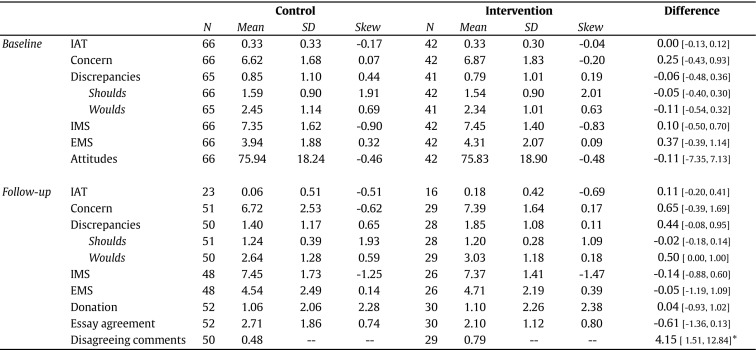

*Note:* For the baseline variables, the “Difference” column shows the mean difference between the intervention and control participants and its 95% CI. For the follow-up variables, the “Difference” column shows the difference and 95% CI, controlling for the [baseline measurement](https://www-sciencedirect-com.ezproxy.spu.edu/topics/psychology/baseline-measurement) of the variable in question (if the variable was measured at baseline). For the disagreeing comments variable, this difference is an odds ratio rather than a mean difference.

#### 3.4.1. Longevity of change in Phase 1 outcomes

As shown in Table 7, there was modest evidence that intervention participants had greater reported woulds than control participants, *b* = 0.499, 95% CI = [− 0.003, 1.001], though the 95% CI for this difference overlapped slightly with 0. There was no evidence of any other differences between the Phase 1 outcomes, though the descriptive difference in concern (intervention *M* = 7.39, *SD* = 1.64; control *M* = 6.72, *SD* = 2.53) was in the predicted direction. Our somewhat low power means that it is ambiguous whether the difference in concern that we observed in Phase 1 has faded by Phase 2 or if our sample is simply too small to detect an enduring difference.

#### 3.4.2. Behavioral measures

Both intervention and control participants disagreed privately with the essay's content; rated agreement in both groups was well below the scale midpoint of 4 (*M* = 2.48, *SD* = 1.65). There was no evidence that the degree of private disagreement differed by condition, intervention *M* = 2.10, *SD* = 1.12, control *M* = 2.71, *SD* = 1.86, *M*<sub>*diff*</sub> = 0.61, 95% CI = [− 0.13, 1.36]. However, there was evidence that intervention participants were more likely to post a public comment disagreeing with the premise that stereotypes were harmless. Whereas 48% of control participants wrote a disagreeing comment, 79% of intervention participants wrote one, *OR* = 4.15, 95% CI = [1.51, 12.84]. Only 25 participants chose to donate any amount to the Center for Social Inclusion, and the amount donated did not differ by condition, intervention *M* = $1.10, *SD* = $2.26, control *M* = $1.06, *SD* = $2.06, *M*<sub>*diff*</sub> = $0.04, 95% CI = [$-0.93, $1.02].

## 4. General discussion

Consistent with the results reported by Devine et al. (2012), we found that the habit-breaking intervention produced an enduring impact on concern about discrimination. Although the present study replicated the intervention's effect on concern, its results related to should-would discrepancies and the IAT were not fully consistent with those reported by Devine and colleagues. Devine and colleagues found that the habit-breaking intervention produced an enduring increase in discrepancies by increasing woulds, whereas we found that the initial increase in woulds declined back to baseline in the latter part of the study. In addition, Devine and colleagues found that only intervention participants declined in their IAT scores, whereas we found that both intervention and control participants exhibited this decrease.

Extending the original work, we found that in the two weeks following the manipulation, intervention participants were more likely to (1) notice bias in the world around them, (2) label any bias (in themselves, others, or society) as wrong, and (3) have interracial interactions with relative strangers (as opposed to friends and family). Two years later, intervention participants were more likely to confront bias by writing comments disagreeing with an essay advocating stereotyping. We believe that, despite some ambiguities in our findings, they provide compelling evidence that the prejudice habit-breaking intervention causes its recipients to recognize bias and its consequences for minorities, then address it in the world around them.

### 4.1. Replication inconsistencies

The present study has a much larger sample size than the study reported by Devine and colleagues. This means that, as long as the present study is a fair test of the effects of the habit-breaking intervention, it is more likely that the effects on implicit bias and discrepancies reported by Devine and colleagues are false positives than that the present results are false negatives. However, the six differences in procedure outlined in Table 1 complicate this interpretation – the new procedural elements in the present study may have masked the habit-breaking intervention's true effects. Of these differences, we believe those most likely to interfere are the changes to the follow-up administration schedule. For example, the frequent assessment schedule may have focused the participants' attention on race-related issues, which could have interfered with the effect of the intervention on should-would discrepancies. After the initial spike in discrepancies, intervention participants may have either worked to reduce their biases or compared their own behavior to the new biases that they observed in other people, either of which may have caused them to revise their beliefs about their biases back to their baseline levels. As another example, the high frequency of IAT administration could have given participants sufficient practice to “beat” the IAT (Banse et al., 2001, Kim, 2003, Lai et al., 2014, Steffens, 2004). If these practice effects are not additive with the habit-breaking intervention's true effects, they could result in similar decreases in IAT scores in both the control and the intervention conditions, which would mask a true non-zero effect of the intervention on implicit bias.

Ultimately, the precise reasons for the differences between our findings and those reported by Devine et al. (2012) are ambiguous. Regardless, we replicated the original effect of the habit-breaking intervention on concern, which gives us confidence that this effect is robust. The habit-breaking intervention's impact on concern amounted to an estimated difference of 0.42 scale units at the end of the 14-day period of Phase 1. Until we obtain population-level evidence about the typical distribution of concern in representative samples, the pragmatic importance of a difference this size is unclear. However, as we will describe in more detail below, both our mechanism analyses and general theory about the self suggest that producing change in concern may have considerable theoretical importance to the bias reducing process. As we will argue, this theoretical importance may eclipse that of implicit bias.

### 4.2. The habit-breaking intervention's mechanisms of change

Our analyses of reported strategy use and the quantity of race-related thoughts, race-related conversations, and interracial interactions suggest that none of these is likely responsible for producing the intervention's effects. The habit-breaking intervention does not change these variables, and with the exception of the quantity of interracial interactions, few of these variables were associated with implicit bias, concern, or discrepancies. In contrast, three dimensions of the content of race-related thoughts, race-related conversations, and interracial interactions differed as a function of the intervention. Participants who completed the habit-breaking intervention were slightly more likely to mention spending time with unfamiliar Black people. Intervention participants were also more likely to mention instances in which others acted with bias and more likely to label any biases they observed (in themselves, others, or society) as wrong.

In particular, noticing the biases of others and labeling biases as wrong were both associated with follow-up concern, even controlling for the intervention's effects. These results suggest that noticing the biases of others and labeling biases as wrong serve as mechanisms through which the habit-breaking intervention increases the degree to which people think discrimination is a problem. If increased concern provokes people to pay more attention to biases in the external environment, concern could be implicated in a recursive, self-sustaining process. A recursive relationship between concern and sensitivity to bias in the external environment could be one reason for the persistence of the intervention's effects. If true, these speculations suggest a potential means through which researchers and practitioners could further enhance the intervention's effectiveness: encourage people to attend to the biases of others in their daily life.

Overall, our results suggest that the habit-breaking intervention does not primarily exert its effects through the strategies the participants learn, nor does it exert its effects by changing the raw quantity of race-related thoughts, race-related conversations, or interracial interactions. Instead, the habit-breaking intervention increases people's sensitivity to bias, particularly when others act with bias, and increases the probability that, when a person encounters bias, he or she will label that bias as wrong. The process of detecting bias in others and labeling it as wrong may in turn provoke concern about racial discrimination, just as the concern may itself provoke the detection of future bias.

### 4.3. The habit-breaking intervention and long-term change

Finally, we uncovered evidence that some of the impact of the habit-breaking intervention is truly long-lasting. Intervention participants were more likely than control participants to publicly object to an essay arguing that stereotypes are useful two years after the administration of the intervention. It is noteworthy that the process of identifying the biased behavior in another person, labeling it as such, and speaking out about it in a public forum is quite similar to the processes that we uncovered in the content of participants' race-related thoughts and conversations from Phase 1. In this sense, the commenting measure provides a good match with the processes that underlie the habit-breaking intervention effects, and the difference in objecting comments at Phase 2 suggests that these processes persisted two years after the intervention was administered. However, we temper this interpretation by noting that our Phase 2 sample was somewhat small, and the true effect of the habit-breaking intervention on the tendency to object to biases may therefore be somewhat smaller than we report here (Button et al., 2013). Nevertheless, we believe the Phase 2 data provide tentative, encouraging evidence as to the longevity of the habit-breaking intervention's effects.

Why do the effects of the habit-breaking intervention persist? One compelling account stems from Rokeach's theory of the self (Rokeach, 1973). This theory holds that behavior is governed by a self-system that is arranged hierarchically around a person's self-concept (Rokeach, 1973). All aspects of the self are affected to some degree by the social environment. However, the aspects that are most central to the self-concept, such as values, are highly resistant to environmentally induced change precisely because such changes require the reorganization of other components lower in the hierarchy. By the same token, the more peripheral aspects of the self, such as stereotypic associations, are highly susceptible to environmental influence because they require no such reorganization (Forscher et al., 2017).<sup>7</sup>

Rokeach's theory offers a useful lens for thinking about psychological change processes. From the perspective of a person designing an intervention, the decision as to whether to target processes central or peripheral to the self-concept offers a tradeoff. Centrally located processes (e.g., values) may be more difficult to change initially, but once initiated, a change can spur a large-scale reorganization of the self-system (Rokeach, 1973). Supported by the newly restructured self-system, the change is also likely to endure despite possibly countervailing environmental influences. In contrast, peripheral processes (e.g., stereotypic associations) are highly susceptible to intervention, at least in the short term. However, because these changes are not buffered by a newly reorganized self-system, they are more likely to be erased by countervailing environmental influences with the passage of time (Lai et al., 2016).

If we apply this analysis to the habit-breaking intervention, we see that the primary targets of change are not the processes that are central to the self-concept. Indeed, in both the data presented by Devine et al. (2012) and in our Phase 2 data, the internal motivation to respond without prejudice, which stems from a person's core egalitarian values, did not change as a function of the intervention. Likewise, the habit-breaking intervention does not directly target automatic processes like implicit bias. Rather, the primary targets of change are beliefs or knowledge – knowledge about how biases can affect behavior unintentionally, whether one's own behavior is or could be biased, and whether the unintentionally biased behavior has adverse consequences. Knowledge is more central to the self-concept than are automatic associations, but less central than values. Knowledge may therefore be an effective target for intervention – it is flexible enough to be influenced by new information and central enough to the self-concept to support the continuation of intervention-initiated changes.

Changing processes that are central to the self may be a necessary but not sufficient condition for producing enduring change. For truly long-term change, it may be necessary for a person to establish patterns of behavior that support the newly changed psychological processes (Miller et al., 2017, Yeager and Walton, 2011). In this sense, the habit-breaking intervention's effects on people's tendencies to notice and label bias may have been critical for the intervention's persistence because these behaviors may have created a feedback loop with people's increased concern about discrimination – an increased tendency to notice and label the biases of others should lead to increased concern, and increased concern should also lead to noticing and labeling the biases of others.

An important implication of this analysis is that the processes that lead to the persistence of an intervention's effects are unlikely to be captured by conventional, widely-used implicit measures. Unintentional bias is a broad construct caused by a range of affective, motivational, cognitive, and behavioral processes, and responses on implicit measures only tap a small range of these processes. According to our analysis, these processes are also the ones least likely to support long-term intervention-initiated changes because they are not central to the self-concept. It may be time for intervention researchers to look beyond implicit measures by crafting interventions that target more central psychological processes and by evaluating the effectiveness of these interventions with longitudinal assessments of behaviors that contribute to recursive feedback loops.

## 5. Conclusion

Evidence-based interventions are needed to overcome psychological biases. The prejudice habit-breaking intervention remains a highly promising candidate for empowering people to reduce their own biases through awareness, concern, and effort. Although we did not replicate the habit-breaking intervention's effects on IAT scores, we did partially replicate its effects on discrepancies and fully replicate its effects on concern about discrimination. Moreover, change in concern seems to be both persistent and associated with change in a broad range of psychological processes related to one's orientation toward oneself and the social environment. Intervention participants were more likely to interact with Black strangers, were more likely to report noticing bias and to label it as wrong, and, two years later, were more likely to confront bias in others. Taken together, we believe this study represents promising evidence for the habit-breaking intervention's effectiveness in producing lasting psychological change.

## Open practices

This article earned Open Materials and Open Data badges for transparent practices. Materials and data are available at https://osf.io/a3c8h/.

## References

**Apfelbaum et al., 2008**

E.P. Apfelbaum, S.R. Sommers, M.I. Norton

**Seeing race and seeming racist? Evaluating strategic colorblindness in social interaction**

Journal of Personality and Social Psychology, 95 (2008), pp. 918-932

[CrossRef](https://doi.org/10.1037/a0011990)[View Record in Scopus](https://www.scopus.com/inward/record.url?eid=2-s2.0-54949102337&partnerID=10&rel=R3.0.0)[Google Scholar](https://scholar.google.com/scholar?q=Seeing%20race%20and%20seeming%20racist%20Evaluating%20strategic%20colorblindness%20in%20social%20interaction)

**Banse et al., 2001**

R. Banse, J. Seise, N. Zerbes

**Implicit attitudes towards homosexuality: Reliability, validity, and controllability of the IAT**

Experimental Psychology, 48 (2001), pp. 145-160

[CrossRef](https://doi.org/10.1026//0949-3946.48.2.145)[View Record in Scopus](https://www.scopus.com/inward/record.url?eid=2-s2.0-0035237348&partnerID=10&rel=R3.0.0)Google Scholar

**Bates et al., 2015**

D. Bates, M. Mächler, B. Bolker, S. Walker

**Fitting linear mixed-effects models using **lme4****

Journal of Statistical Software, 67 (2015)

[Google Scholar](https://scholar.google.com/scholar_lookup?title=Fitting%20linear%20mixed-effects%20models%20using%20lme4&publication_year=2015&author=D.%20Bates&author=M.%20M%C3%A4chler&author=B.%20Bolker&author=S.%20Walker)

**Bertrand and Mullainathan, 2004**

M. Bertrand, S. Mullainathan

**Are Emily and Greg more employable than Lakisha and Jamal? A field experiment on labor market discrimination**

American Economic Review, 94 (2004), pp. 991-1013

[CrossRef](https://doi.org/10.1257/0002828042002561)[Google Scholar](https://scholar.google.com/scholar?q=Are%20Emily%20and%20Greg%20more%20employable%20than%20Lakisha%20and%20Jamal%20A%20field%20experiment%20on%20labor%20market%20discrimination)

**Blair et al., 2001**

I.V. Blair, J.E. Ma, A.P. Lenton

**Imagining stereotypes away: The moderation of implicit stereotypes through mental imagery**

Journal of Personality and Social Psychology, 81 (2001), pp. 828-841

[View Record in Scopus](https://www.scopus.com/inward/record.url?eid=2-s2.0-85047685721&partnerID=10&rel=R3.0.0)Google Scholar

**Brewer, 1988**

M. Brewer

**A dual-process model of impression formation**

T. Srull, R. Wyer (Eds.), Advances in social cognition, L. Erlbaum Associates, Hillsdale N.J. (1988), pp. 1-36

[View Record in Scopus](https://www.scopus.com/inward/record.url?eid=2-s2.0-79952818720&partnerID=10&rel=R3.0.0)[Google Scholar](https://scholar.google.com/scholar_lookup?title=A%20dual-process%20model%20of%20impression%20formation&publication_year=1988&author=M.%20Brewer)

**Button et al., 2013**

K.S. Button, J.P.A. Ioannidis, C. Mokrysz, B.A. Nosek, J. Flint, E.S.J. Robinson, M.R. Munafò

**Power failure: Why small sample size undermines the reliability of neuroscience**

Nature Reviews Neuroscience, 14 (2013), pp. 365-376

[CrossRef](https://doi.org/10.1038/nrn3475)[View Record in Scopus](https://www.scopus.com/inward/record.url?eid=2-s2.0-84876665206&partnerID=10&rel=R3.0.0)Google Scholar

**Canning and Harackiewicz, 2015**

E.A. Canning, J.M. Harackiewicz

**Teach it, don't preach it: The differential effects of directly-communicated and self-generated utility–value information**

Motivation Science, 1 (2015), pp. 47-71

[CrossRef](https://doi.org/10.1037/mot0000015)[View Record in Scopus](https://www.scopus.com/inward/record.url?eid=2-s2.0-84987709012&partnerID=10&rel=R3.0.0)[Google Scholar](https://scholar.google.com/scholar?q=Teach%20it,%20dont%20preach%20it:%20The%20differential%20effects%20of%20directly-communicated%20and%20self-generated%20utilityvalue%20information)

**Carnes et al., 2015**

M. Carnes, P.G. Devine, L. Baier Manwell, A. Byars-Winston, E. Fine, C.E. Ford, ..., J. Sheridan

**The effect of an intervention to break the gender bias habit for faculty at one institution: A cluster randomized, controlled trial**

Academic Medicine, 90 (2015), pp. 221-230

[View Record in Scopus](https://www.scopus.com/inward/record.url?eid=2-s2.0-84922409325&partnerID=10&rel=R3.0.0)Google Scholar

**Cialdini et al., 1981**

R.B. Cialdini, R.E. Petty, J.T. Cacioppo

**Attitude and attitude change**

Annual Review of Psychology, 32 (1) (1981), pp. 357-404

[CrossRef](https://doi.org/10.1146/annurev.ps.32.020181.002041)[View Record in Scopus](https://www.scopus.com/inward/record.url?eid=2-s2.0-70350375331&partnerID=10&rel=R3.0.0)[Google Scholar](https://scholar.google.com/scholar_lookup?title=Attitude%20and%20attitude%20change&publication_year=1981&author=R.B.%20Cialdini&author=R.E.%20Petty&author=J.T.%20Cacioppo)

**Cox and Devine, 2015**

W.T. Cox, P.G. Devine

**Stereotypes possess heterogeneous directionality: A theoretical and empirical exploration of stereotype structure and content**

PloS One, 10 (3) (2015), Article e0122292

[CrossRef](https://doi.org/10.1371/journal.pone.0122292)[View Record in Scopus](https://www.scopus.com/inward/record.url?eid=2-s2.0-84926205063&partnerID=10&rel=R3.0.0)Google Scholar

**Devine, 1989**

P.G. Devine

**Stereotypes and prejudice: Their automatic and controlled components**

Journal of Personality and Social Psychology, 56 (1989), pp. 5-18

[View Record in Scopus](https://www.scopus.com/inward/record.url?eid=2-s2.0-25144451557&partnerID=10&rel=R3.0.0)[Google Scholar](https://scholar.google.com/scholar_lookup?title=Stereotypes%20and%20prejudice%3A%20Their%20automatic%20and%20controlled%20components&publication_year=1989&author=P.G.%20Devine)

**Devine et al., 2012**

P.G. Devine, P.S. Forscher, A.J. Austin, W.T.L. Cox

**Long-term reduction in implicit race bias: A prejudice habit-breaking intervention**

Journal of Experimental Social Psychology, 48 (2012), pp. 1267-1278

[Article](https://www-sciencedirect-com.ezproxy.spu.edu/science/article/pii/S0022103112001369)[Download PDF](https://www-sciencedirect-com.ezproxy.spu.edu/science/article/pii/S0022103112001369/pdfft?md5=779e1a202956a6ad3688e3cabaedbb7a&pid=1-s2.0-S0022103112001369-main.pdf)[View Record in Scopus](https://www.scopus.com/inward/record.url?eid=2-s2.0-84865616183&partnerID=10&rel=R3.0.0)Google Scholar

**Devine et al., 1991**

P.G. Devine, M.J. Monteith, J.R. Zuwerink, A.J. Elliot

**Prejudice with and without compunction**

Journal of Personality and Social Psychology, 60 (1991), pp. 817-830

[View Record in Scopus](https://www.scopus.com/inward/record.url?eid=2-s2.0-0000634535&partnerID=10&rel=R3.0.0)[Google Scholar](https://scholar.google.com/scholar_lookup?title=Prejudice%20with%20and%20without%20compunction&publication_year=1991&author=P.G.%20Devine&author=M.J.%20Monteith&author=J.R.%20Zuwerink&author=A.J.%20Elliot)

**Enders and Tofighi, 2007**

C.K. Enders, D. Tofighi

**Centering predictor variables in cross-sectional multilevel models: A new look at an old issue**

Psychological Methods, 12 (2007), pp. 121-138

[CrossRef](https://doi.org/10.1037/1082-989X.12.2.121)[View Record in Scopus](https://www.scopus.com/inward/record.url?eid=2-s2.0-34548463099&partnerID=10&rel=R3.0.0)Google Scholar

**Fiske, 1998**

S. Fiske

**Stereotyping, prejudice, and discrimination**

S. Fiske, D. Gilbert, L. Gardner (Eds.) (4th ed.), The handbook of social psychology, The McGraw-Hill, Boston [etc.] (1998), pp. 357-411

[Google Scholar](https://scholar.google.com/scholar_lookup?title=Stereotyping%2C%20prejudice%2C%20and%20discrimination&publication_year=1998&author=S.%20Fiske)

**Fiske and Neuberg, 1990**

S.T. Fiske, S.L. Neuberg

**A continuum of impression formation, from category-based to individuating processes: Influences of information and motivation on attention and interpretation**

M.P. Zanna (Ed.), Advances in experimental social psychology, Vol. 23, Elsevier (1990), pp. 1-74

[Article](https://www-sciencedirect-com.ezproxy.spu.edu/science/article/pii/S0065260108603172)[Download PDF](https://www-sciencedirect-com.ezproxy.spu.edu/science/article/pii/S0065260108603172/pdf?md5=815db8af7a4186aa856a76b8ed8db648&pid=1-s2.0-S0065260108603172-main.pdf)[View Record in Scopus](https://www.scopus.com/inward/record.url?eid=2-s2.0-77957060940&partnerID=10&rel=R3.0.0)Google Scholar

**Forscher et al., 2017**

P.S.* Forscher, C.K.* Lai, J. Axt, C.R. Ebersole, M. Herman, B.A. Nosek

**A meta-analysis of change in implicit bias**

Retrieved from

http://osf.io/preprints/psyarxiv/dv8tu (2017, Feb. 17)

[Google Scholar](https://scholar.google.com/scholar?q=A%20meta-analysis%20of%20change%20in%20implicit%20bias)

**Galinsky and Moskowitz, 2000**

A.D. Galinsky, G.B. Moskowitz

**Perspective-taking: Decreasing stereotype expression, stereotype accessibility, and in-group favoritism**

Journal of Personality and Social Psychology, 78 (2000), pp. 708-724

[View Record in Scopus](https://www.scopus.com/inward/record.url?eid=2-s2.0-0034168090&partnerID=10&rel=R3.0.0)Google Scholar

**Greenwald et al., 1998**

A.G. Greenwald, D.E. McGhee, J.L. Schwartz

**Measuring individual differences in implicit cognition: The implicit association test**

Journal of Personality and Social Psychology, 74 (1998), pp. 1464-1480

[View Record in Scopus](https://www.scopus.com/inward/record.url?eid=2-s2.0-0032084985&partnerID=10&rel=R3.0.0)Google Scholar

**Greenwald et al., 2003**

A.G. Greenwald, B.A. Nosek, M.R. Banaji

**Understanding and using the implicit association test: I. An improved scoring algorithm**

Journal of Personality and Social Psychology, 85 (2003), pp. 197-216

[CrossRef](https://doi.org/10.1037/0022-3514.85.2.197)[View Record in Scopus](https://www.scopus.com/inward/record.url?eid=2-s2.0-0042549769&partnerID=10&rel=R3.0.0)Google Scholar

**Hulleman and Harackiewicz, 2009**

C.S. Hulleman, J.M. Harackiewicz

**Promoting interest and performance in high school science classes**

Science, 326 (2009), pp. 1410-1412

[CrossRef](https://doi.org/10.1126/science.1177067)[View Record in Scopus](https://www.scopus.com/inward/record.url?eid=2-s2.0-71549158525&partnerID=10&rel=R3.0.0)[Google Scholar](https://scholar.google.com/scholar_lookup?title=Promoting%20interest%20and%20performance%20in%20high%20school%20science%20classes&publication_year=2009&author=C.S.%20Hulleman&author=J.M.%20Harackiewicz)

**Ibrahim and Molenberghs, 2009**

J.G. Ibrahim, G. Molenberghs

**Missing data methods in longitudinal studies: A review**

TEST, 18 (2009), pp. 1-43

[CrossRef](https://doi.org/10.1007/s11749-009-0138-x)[View Record in Scopus](https://www.scopus.com/inward/record.url?eid=2-s2.0-60749123292&partnerID=10&rel=R3.0.0)[Google Scholar](https://scholar.google.com/scholar_lookup?title=Missing%20data%20methods%20in%20longitudinal%20studies%3A%20A%20review&publication_year=2009&author=J.G.%20Ibrahim&author=G.%20Molenberghs)

**Janis and King, 1954**

I.L. Janis, B.T. King

**The influence of role playing on opinion change**

The Journal of Abnormal and Social Psychology, 49 (1954), pp. 211-218

[CrossRef](https://doi.org/10.1037/h0056957)[View Record in Scopus](https://www.scopus.com/inward/record.url?eid=2-s2.0-0000741953&partnerID=10&rel=R3.0.0)[Google Scholar](https://scholar.google.com/scholar_lookup?title=The%20influence%20of%20role%20playing%20on%20opinion%20change&publication_year=1954&author=I.L.%20Janis&author=B.T.%20King)

**Kim, 2003**

D. Kim

**Voluntary controllability of the Implicit Association Test (IAT)**

Social Psychology Quarterly, 66 (2003), p. 83

[CrossRef](https://doi.org/10.2307/3090143)[View Record in Scopus](https://www.scopus.com/inward/record.url?eid=2-s2.0-0037367305&partnerID=10&rel=R3.0.0)[Google Scholar](https://scholar.google.com/scholar?q=Voluntary%20controllability%20of%20the%20Implicit%20Association%20Test)

**Lai et al., 2014**

C.K. Lai, M. Marini, S.A. Lehr, C. Cerruti, J.-E. Shin, J.A. Joy-Gaba, ..., B.A. Nosek

**Reducing implicit racial preferences: I. A comparative investigation of 17 interventions**

Journal of Experimental Psychology: General, 143 (2014), pp. 1765-1785

[CrossRef](https://doi.org/10.1037/a0036260)[View Record in Scopus](https://www.scopus.com/inward/record.url?eid=2-s2.0-84905119237&partnerID=10&rel=R3.0.0)Google Scholar

**Lai et al., 2016**

C.K. Lai, A.L. Skinner, E. Cooley, S. Murrar, M. Brauer, T. Devos, ..., B.A. Nosek

**Reducing implicit racial preferences: II. Intervention effectiveness across time**

Journal of Experimental Psychology: General, 145 (2016), pp. 1001-1016

[CrossRef](https://doi.org/10.1037/xge0000179)[View Record in Scopus](https://www.scopus.com/inward/record.url?eid=2-s2.0-84974533973&partnerID=10&rel=R3.0.0)Google Scholar

**McClelland et al., 2010**

J.L. McClelland, M.M. Botvinick, D.C. Noelle, D.C. Plaut, T.T. Rogers, M.S. Seidenberg, L.B. Smith

**Letting structure emerge: Connectionist and dynamical systems approaches to cognition**

Trends in Cognitive Sciences, 14 (2010), pp. 348-356

[Article](https://www-sciencedirect-com.ezproxy.spu.edu/science/article/pii/S1364661310001245)[Download PDF](https://www-sciencedirect-com.ezproxy.spu.edu/science/article/pii/S1364661310001245/pdfft?md5=aa66087253483f15c3f1ffe2e46c31f0&pid=1-s2.0-S1364661310001245-main.pdf)[View Record in Scopus](https://www.scopus.com/inward/record.url?eid=2-s2.0-77955270906&partnerID=10&rel=R3.0.0)Google Scholar

**Miller et al., 2017**

D.T. Miller, J.E. Dannals, J.J. Zlatev

**Behavioral Processes in Long-Lag Intervention Studies**

Perspectives on Psychological Science, 12 (3) (2017), pp. 454-467, 10.1177/1745691616681645

[CrossRef](https://doi.org/10.1177/1745691616681645)[View Record in Scopus](https://www.scopus.com/inward/record.url?eid=2-s2.0-85019676404&partnerID=10&rel=R3.0.0)[Google Scholar](https://scholar.google.com/scholar_lookup?title=Behavioral%20Processes%20in%20Long-Lag%20Intervention%20Studies&publication_year=2017&author=D.T.%20Miller&author=J.E.%20Dannals&author=J.J.%20Zlatev)

**Monteith, 1993**

M.J. Monteith

**Self-regulation of prejudiced responses: Implications for progress in prejudice-reduction efforts**

Journal of Personality and Social Psychology, 65 (1993), pp. 469-485

[View Record in Scopus](https://www.scopus.com/inward/record.url?eid=2-s2.0-0002117779&partnerID=10&rel=R3.0.0)Google Scholar

**Monteith et al., 2002**

M.J. Monteith, L. Ashburn-Nardo, C.I. Voils, A.M. Czopp

**Putting the brakes on prejudice: On the development and operation of cues for control**

Journal of Personality and Social Psychology, 83 (2002), pp. 1029-1050

[View Record in Scopus](https://www.scopus.com/inward/record.url?eid=2-s2.0-85047673460&partnerID=10&rel=R3.0.0)Google Scholar

**Monteith and Voils, 1998**

M.J. Monteith, C.I. Voils

**Proneness to prejudiced responses: Toward understanding the authenticity of self-reported discrepancies**

Journal of Personality and Social Psychology, 75 (1998), pp. 901-916

[View Record in Scopus](https://www.scopus.com/inward/record.url?eid=2-s2.0-0032176323&partnerID=10&rel=R3.0.0)Google Scholar

**Monteith et al., 2001**

M.J. Monteith, C.I. Voils, L. Ashburn-Nardo

**Taking a look underground: Detecting, interpreting, and reacting to implicit racial biases**

Social Cognition, 19 (2001), pp. 395-417

[View Record in Scopus](https://www.scopus.com/inward/record.url?eid=2-s2.0-0035623545&partnerID=10&rel=R3.0.0)Google Scholar

**Norton et al., 2006**

M.I. Norton, S.R. Sommers, E.P. Apfelbaum, N. Pura, D. Ariely

**Color blindness and interracial interaction: Playing the political correctness game**

Psychological Science, 17 (2006), pp. 949-953

[CrossRef](https://doi.org/10.1111/j.1467-9280.2006.01810.x)[View Record in Scopus](https://www.scopus.com/inward/record.url?eid=2-s2.0-33845319764&partnerID=10&rel=R3.0.0)Google Scholar

**Pettigrew, 1998**

T.F. Pettigrew

**Intergroup contact theory**

Annual Review of Psychology, 49 (1998), pp. 65-85

[View Record in Scopus](https://www.scopus.com/inward/record.url?eid=2-s2.0-0032376574&partnerID=10&rel=R3.0.0)[Google Scholar](https://scholar.google.com/scholar_lookup?title=Intergroup%20contact%20theory&publication_year=1998&author=T.F.%20Pettigrew)

**Pettigrew and Tropp, 2006**

T.F. Pettigrew, L.R. Tropp

**A meta-analytic test of intergroup contact theory**

Journal of Personality and Social Psychology, 90 (2006), pp. 751-783

[CrossRef](https://doi.org/10.1037/0022-3514.90.5.751)[View Record in Scopus](https://www.scopus.com/inward/record.url?eid=2-s2.0-33745196004&partnerID=10&rel=R3.0.0)[Google Scholar](https://scholar.google.com/scholar_lookup?title=A%20meta-analytic%20test%20of%20intergroup%20contact%20theory&publication_year=2006&author=T.F.%20Pettigrew&author=L.R.%20Tropp)

**Plant and Devine, 1998**

E.A. Plant, P.G. Devine

**Internal and external motivation to respond without prejudice**

Journal of Personality and Social Psychology, 75 (1998), pp. 811-832

[View Record in Scopus](https://www.scopus.com/inward/record.url?eid=2-s2.0-0347876906&partnerID=10&rel=R3.0.0)[Google Scholar](https://scholar.google.com/scholar_lookup?title=Internal%20and%20external%20motivation%20to%20respond%20without%20prejudice&publication_year=1998&author=E.A.%20Plant&author=P.G.%20Devine)

**Plant and Devine, 2003**

E.A. Plant, P.G. Devine

**The antecedents and implications of interracial anxiety**

Personality and Social Psychology Bulletin, 29 (2003), pp. 790-801

[View Record in Scopus](https://www.scopus.com/inward/record.url?eid=2-s2.0-0038116820&partnerID=10&rel=R3.0.0)[Google Scholar](https://scholar.google.com/scholar_lookup?title=The%20antecedents%20and%20implications%20of%20interracial%20anxiety&publication_year=2003&author=E.A.%20Plant&author=P.G.%20Devine)

**Plant and Devine, 2009**

E.A. Plant, P.G. Devine

**The active control of prejudice: Unpacking the intentions guiding control efforts**

Journal of Personality and Social Psychology, 96 (2009), pp. 640-652

[CrossRef](https://doi.org/10.1037/a0012960)[View Record in Scopus](https://www.scopus.com/inward/record.url?eid=2-s2.0-62649141437&partnerID=10&rel=R3.0.0)Google Scholar

**Raudenbush and Bryk, 2002**

S.W. Raudenbush, A.S. Bryk

**Hierarchical linear models: Applications and data analysis methods**

(2nd ed.), Sage Publications, Thousand Oaks, CA (2002)

[Google Scholar](https://scholar.google.com/scholar_lookup?title=Hierarchical%20linear%20models%3A%20Applications%20and%20data%20analysis%20methods&publication_year=2002&author=S.W.%20Raudenbush&author=A.S.%20Bryk)

**Richard et al., 2003**

F.D. Richard, C.F. Bond, J.J. Stokes-Zoota

**One hundred years of social psychology quantitatively described**

Review of General Psychology, 7 (2003), pp. 331-363

[View Record in Scopus](https://www.scopus.com/inward/record.url?eid=2-s2.0-0347604000&partnerID=10&rel=R3.0.0)Google Scholar

**Rokeach, 1973**

M. Rokeach

**The nature of human values**

The Free Press, New York (1973)

[Google Scholar](https://scholar.google.com/scholar_lookup?title=The%20nature%20of%20human%20values&publication_year=1973&author=M.%20Rokeach)

**Smedley et al., 2003**

B. Smedley, A. Stith, A. Nelson (Eds.), Unequal treatment: Confronting racial and ethnic disparities in health care, National Academy Press, Washington D.C. (2003)

[Google Scholar](https://scholar.google.com/scholar?q=Unequal%20treatment:%20Confronting%20racial%20and%20ethnic%20disparities%20in%20health%20care)

**Steffens, 2004**

M.C. Steffens

**Is the implicit association test immune to faking?**

Experimental Psychology, 51 (2004), pp. 165-179

[View Record in Scopus](https://www.scopus.com/inward/record.url?eid=2-s2.0-3142544800&partnerID=10&rel=R3.0.0)[Google Scholar](https://scholar.google.com/scholar?q=Is%20the%20implicit%20association%20test%20immune%20to%20faking)

**Stephan and Stephan, 1985**

W.G. Stephan, C.W. Stephan

**Intergroup anxiety**

Journal of Social Issues, 41 (3) (1985), pp. 157-175

[CrossRef](https://doi.org/10.1111/j.1540-4560.1985.tb01134.x)[View Record in Scopus](https://www.scopus.com/inward/record.url?eid=2-s2.0-0022224259&partnerID=10&rel=R3.0.0)[Google Scholar](https://scholar.google.com/scholar_lookup?title=Intergroup%20anxiety&publication_year=1985&author=W.G.%20Stephan&author=C.W.%20Stephan)

**Van Breukelen, 2006**

G.J.P. Van Breukelen

**ANCOVA versus change from baseline had more power in randomized studies and more bias in nonrandomized studies**

Journal of Clinical Epidemiology, 59 (2006), pp. 920-925

[Article](https://www-sciencedirect-com.ezproxy.spu.edu/science/article/pii/S0895435606000813)[Download PDF](https://www-sciencedirect-com.ezproxy.spu.edu/science/article/pii/S0895435606000813/pdfft?md5=cefe89fa2e2c3aa2d602b3cf4dc4d294&pid=1-s2.0-S0895435606000813-main.pdf)[View Record in Scopus](https://www.scopus.com/inward/record.url?eid=2-s2.0-33746708040&partnerID=10&rel=R3.0.0)Google Scholar

**Wickham, 2009**

H. Wickham

**ggplot2: Elegant graphics for data analysis**

Springer, New York, NY (2009)

[Google Scholar](https://scholar.google.com/scholar_lookup?title=ggplot2%3A%20Elegant%20graphics%20for%20data%20analysis&publication_year=2009&author=H.%20Wickham)

**Williams et al., 2003**

D.R. Williams, H.W. Neighbors, J.S. Jackson

**Racial/ethnic discrimination and health: Findings from community studies**

American Journal of Public Health, 93 (2003), pp. 200-208

[CrossRef](https://doi.org/10.2105/AJPH.93.2.200)[View Record in Scopus](https://www.scopus.com/inward/record.url?eid=2-s2.0-0037311382&partnerID=10&rel=R3.0.0)[Google Scholar](https://scholar.google.com/scholar?q=Racialethnic%20discrimination%20and%20health:%20Findings%20from%20community%20studies)

**Yeager and Walton, 2011**

D.S. Yeager, G.M. Walton

**Social-psychological interventions in education: They're not magic**

Review of Educational Research, 81 (2011), pp. 267-301

[CrossRef](https://doi.org/10.3102/0034654311405999)[View Record in Scopus](https://www.scopus.com/inward/record.url?eid=2-s2.0-79955736285&partnerID=10&rel=R3.0.0)[Google Scholar](https://scholar.google.com/scholar?q=Social-psychological%20interventions%20in%20education:%20Theyre%20not%20magic)

**<sup>☆</sup>**

Conceived research: Forscher, Devine; Designed research: Forscher, Mitamura, Devine; Coordinated data collection: Forscher, Mitamura; Coded free response data: Forscher, Mitamura, Dix; Analyzed data: Forscher, Dix; Wrote paper: all authors; Revised paper: all authors.

**<sup>☆☆</sup>**

We'd like to thank Maha Baalbaki, Brittany Drifka, Collin Eckberg, Hannah Kimyon, Keith Knutson, Alyssa Law, Tianrui Li, Mary Martinco, Ryan Massopust, Kelly Nance, Nicole Sather, and Zach Wittrock for their help collecting data for this study.

**<sup>★</sup>**

Preparation of this article was supported by NIH grant 5R01GM111002-02, a Wisconsin Alumni Research Foundation Professorship awarded to the last author, and a National Science Foundation Graduate Research Fellowship (DGE-1256259) awarded to the third author. Data and materials for this project can be found at https://osf.io/a3c8h/.

**<sup>1</sup>**

**<sup>2</sup>**

Five variables were coded but excluded from analyses. Strategy use was excluded because of low interrater reliability (*κ* = 0.56). Thoughts and conversations about the study, whether the race-related conversations occurred in a structured environment, whether the participants confronted another person about their bias, and whether the participants had a negative interracial interaction were excluded because they occurred too infrequently for the GLMEM models to converge (*study* = 60/515, *structured* = 27/249, *confrontation* = 2/249, *negative* = 4/834).

**<sup>3</sup>**

We did not estimate the correlations between random slopes and random intercepts in these models.

**<sup>4</sup>**

These numbers represent predicted values from the GLMEM and therefore cannot be interpreted directly as percentages.

**<sup>5</sup>**

Some participants took multiple follow-ups in the same day, which resulted in erroneously high daily rates due to the short amount of elapsed time between follow-ups. Thus, we excluded responses that occurred less than half a day after the last recorded follow-up from these analyses. We did not estimate the correlations between the random intercepts and slopes in these models.

**<sup>6</sup>**

As with our other analyses using rate variables, we excluded responses that occurred less than half a day after the previously recorded response.

**<sup>7</sup>**

Rokeach's theory is not fully consistent with modern, connectionist views of cognition (see Cox and Devine, 2015, McClelland et al., 2010). A modern connectionist view of cognition might replace the Rokeach's construct of centrality to the self-concept with the construct of the density of the connections between different aspects of the self-structure network. Regardless of which construct one uses, the implications for change processes are similar, so we maintain the “centrality” terminology for ease of communication.

[View Abstract](https://www-sciencedirect-com.ezproxy.spu.edu/science/article/abs/pii/S0022103116306436)

Published by Elsevier Inc.